# PRISM Video Playlists

## YouTube Playlists

[figure not shown]

**Fixing Issues in Prism Repos (Oct 26)**  
A five-part walkthrough of how PRISM repos fix issues with an AI agent, using issue #34 in prism-practice-repo. It goes from writing and assigning the issue, through starting a codespace, branching, planning and fixing, to opening the pull request, merging it and cleaning up.

[figure not shown]

**AI Features from Prism LCA Project (Oct 26)**  
Five demos of PRISM’s AI features. The Prism LCA MCP connects Claude.ai, ChatGPT and the Product Graph Editor’s assistant directly to the LCA engine. The demos run case studies, chart results, and search the BAFU background database to find and compare alternative materials for a plastic broom.

[figure not shown]

**Prism LCA Org Introduction and Pull Requests (Oct 26)**  
An introduction to the prism-lca GitHub organization and its pull request workflow. It tours the org page and project board, writes an issue in prism-practice-repo, and fixes it twice, once with Codex and once with Claude Code. Each fix goes through a pull request that a maintainer merges.

[figure not shown]

**PRISM Product Graph Editor (Oct 26)**  
An eight-part tour of the Product Graph Editor, PRISM’s main web app. It covers where the app and engine live, the graph editor and its YAML files, then each results tab: inventory, impact analysis, process results, contribution tree and Sankey graphs, using the cotton fiber and jacket templates.

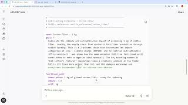

**Life Cycle Assessment MCP Introduction (Jul 26)**  
A four-part introduction to LCA using the Prism LCA MCP in Claude.ai and the cotton fiber case study. It covers installing the connector, product graphs and unit processes, running the LCA to get the inventory and scaling, and calculating TRACI 2.1 impact scores from characterization factors.

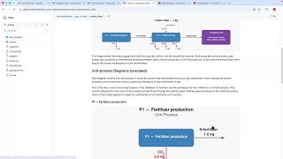

**OpenLCA and Mock LCA Tests (Jul 26)**  
Three videos on checking the Prism LCA engine against OpenLCA. They tour the case studies in the lca-mock-tests repo, install OpenLCA, and import the cotton fiber case study to confirm it gives the same inventory and TRACI 2.1 impact scores as the Prism MCP.

## Fixing Issues in Prism Repos (Oct 26)

[figure not shown]

**[Playlist: Fixing Issues in Prism Repos](https://www.youtube.com/playlist?list=PLWZRArvUaVQI)** · 5 videos  
A five-part walkthrough of how PRISM repos fix issues with an AI agent, using issue #34 in prism-practice-repo. It goes from writing and assigning the issue, through starting a codespace, branching, planning and fixing, to opening the pull request, merging it and cleaning up.

[figure not shown]

**1. [Fixing Issues in Prism Repos](https://www.youtube.com/watch?v=IHpj3DbrOhk)**  
How PRISM issues get fixed. An assigned issue moves to In Progress on the project board. An agent fixes it on its own branch, then a code owner merges the pull request, which closes the issue automatically.

[figure not shown]

**2. [Creating a New Issue in A Repo](https://www.youtube.com/watch?v=no0cgICQUsk)**  
Writes issue #34: create `docs/calvinw.md` saying “hello from Calvin W”, with a goal and acceptance criteria. After assigning it, tours the project board’s board and table views and outlines the flow: codespace, issue, branch, plan, fix, test, pull request.

[figure not shown]

**3. [Creating a Codespace on Main And Asking Agent for Issue](https://www.youtube.com/watch?v=wAJURzAaGLQ)**  
Starts a codespace on main, logs in to Claude Code, and asks for assigned issues. The agent finds #34 and, following `AGENTS.md`, offers to branch from an up-to-date main and write a plan first. Tip: one issue at a time.

[figure not shown]

**4. [Making the Issue Branch, Creating the Plan, Fixing the Bug](https://www.youtube.com/watch?v=E8xySDxowoE)**  
The agent creates the issue-34 branch and drafts a plan with the goal, acceptance criteria and testing steps. After approval it pushes the plan, then the fix. Anyone can push to branches other than main. The fix is checked on GitHub.

[figure not shown]

**5. [Opening the Pull Request to Merge Issue Branch](https://www.youtube.com/watch?v=lcKqbSLwx3w)**  
The agent opens a pull request. A code owner merges it on GitHub, closing #34, deleting the branch and moving the card to Done. The agent then switches to main, pulls and removes the local branch. The plan stays in `plans/`.

## AI Features from Prism LCA Project (Oct 26)

[figure not shown]

**[Playlist: AI Features from Prism LCA Project](https://www.youtube.com/playlist?list=PLF7QVJHf7fjU)** · 5 videos  
Five demos of PRISM’s AI features. The Prism LCA MCP connects Claude.ai, ChatGPT and the Product Graph Editor’s assistant directly to the LCA engine. The demos run case studies, chart results, and search the BAFU background database to find and compare alternative materials for a plastic broom.

[figure not shown]

**1. [AI Assistant in Product Graph Editor](https://www.youtube.com/watch?v=V4bxUoPtKSs)**  
A first look at the Product Graph Editor’s AI assistant. It sees the graph, YAML, settings and results, and calls the Prism LCA MCP to run the engine. It summarizes a graph, moves to the results page and explains contribution tree values.

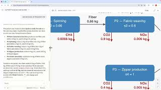

**2. [Using the Prism LCA MCP from Claude.ai](https://www.youtube.com/watch?v=pclNFJ8pTxs)**  
Adds the Prism LCA MCP to Claude.ai as a custom connector and tours its tools. With the jacket case study, Claude shows the scaled graph, runs the LCA, builds a contribution tree and table, and explains how each process is scaled.

[figure not shown]

**3. [Using the Prism LCA MCP from ChatGPT](https://www.youtube.com/watch?v=4cJnidPVtWI)**  
Adds the same MCP to ChatGPT as a custom MCP server. With the wool yarn case study, ChatGPT shows the structured and scaled graphs and charts the impact categories, a contribution tree and the inventory, with a few labeling mistakes.

[figure not shown]

**4. [Plastic Broom LCA with Background (BAFU database) in Claude.ai](https://www.youtube.com/watch?v=N8eWRTyb5P0)**  
Explains foreground and background processes using OpenLCA’s plastic broom, linked to the Swiss BAFU database. Claude.ai describes BAFU, reads the broom’s YAML and finds PLA alternatives. A commodity plastic lowered both climate change and acidification (cradle-to-gate).

[figure not shown]

**5. [Plastic Broom (BAFU linked) in Product Graph Editor](https://www.youtube.com/watch?v=mJjvz7FFXNM)**  
The broom analysis in the Product Graph Editor’s chat, using a GPT model through OpenRouter. The assistant searches BAFU, edits the YAML to swap PLA for HDPE and reruns the LCA. Lesson: save results before comparing scenarios.

## Prism LCA Org Introduction and Pull Requests (Oct 26)

[figure not shown]

**[Playlist: Prism LCA Org Introduction and Pull Requests](https://www.youtube.com/playlist?list=PLLp4EmvQ0GEg)** · 5 videos  
An introduction to the prism-lca GitHub organization and its pull request workflow. It tours the org page and project board, writes an issue in prism-practice-repo, and fixes it twice, once with Codex and once with Claude Code. Each fix goes through a pull request that a maintainer merges.

[figure not shown]

**1. [Introduction to Prism org site in Github](https://www.youtube.com/watch?v=lPOnk9LaVOM)**  
A tour of the prism-lca GitHub organization: its repos, the public and member views, and the Prism LCA project board, where issues from every repo move from To Do to In Progress to Done. Changes reach main only through pull requests that maintainers merge.

[figure not shown]

**2. [Creating an Issue in a Prism Repo](https://www.youtube.com/watch?v=RR9syIty1kU)**  
Why everyone should write issues, and how pull requests protect main. Writes an issue asking Calvin to add his name to the README, with tips on formatting and adding screenshots for the agent, then assigns it and shows it under In Progress on the board.

[figure not shown]

**3. [Starting Codex to Fix an Issue For a Repo](https://www.youtube.com/watch?v=-vJJwbYps50)**  
Starts a codespace on main, waits while setup installs the agents, then runs `codex –yolo` and signs in with a device code. Covers choosing the model and reasoning level and checking `/usage`. Tip: skip fast mode, which uses tokens twice as fast.

[figure not shown]

**4. [Fixing the Issue and Issuing the Pull Request](https://www.youtube.com/watch?v=52zfX2sEXkY)**  
Codex finds issue #10, adds Calvin’s name to the README, and opens a pull request on a new branch. A maintainer merges it on GitHub, where `Fixes #10` closes the issue and the board moves it to Done. Then the codespace is deleted.

[figure not shown]

**5. [CLAUDE CODE version - Fixing the Issue](https://www.youtube.com/watch?v=Y8cc6OAGqyo)**  
The same fix with Claude Code: run `claude –dangerously-skip-permissions`, sign in by pasting the login code back, and have Claude add Elena’s name to the README and open a pull request. After the merge, Claude cleans up the branch and closes the issue.